# Results and Interpretations

2025-11-04

## Introduction

In the methodology section, a variety of random forest, XGboost, K nearest neighbours, logistic regression and support vector machine models were developed and the “best” for each type was picked, based on the AUC value, to be a condidate for the final model in this project. In this section, these five models will be compared against eachother and the best overall model to predict whether a company will go bankrupt within the next year will be decided upon. Again, AUC is valued as the most important perormance metric in decided this however other performance metrics will also be discussed.

## Testing the Models

The best 5 models have been loaded into this document and will now be used to make predictions on the final test set. This test set is completely unseen by any of the models previously so will provide a standard base-line for testing the performance of these models. Below is the code for this:

```r
#testing svm
svm_pred <- predict(svm_model, x_test_svm, probability = TRUE)
svm_class <- factor(svm_pred, levels = levels(y_test))

#testing knn
knn_pred <- predict(knn_model, x_test_knn, type = 'raw')
knn_prob <- predict(knn_model, x_test_knn, type ='prob')
#testing logit
logit_pred = predict(logit_model, test_logist, type ="response")
logit_class <- factor(ifelse(logit_pred > 0.5, "failed", "alive"), levels = c("alive","failed"))
#testing xgboost
xgb_pred = predict(xgb_model, dtest)
xgb_class <- factor(ifelse(xgb_pred > 0.5, "failed", "alive"), levels = c("alive","failed"))
#testing random forest
rf_pred = predict(rf_model, df_test_noscale)
rf_prob = predict(rf_model, test_rf, type = 'prob')
```

## ROC Curves and AUC

We will start by taking a look at the ROC curves. The ROC curve is a graphical representation of a classification model’s performance. It plots the True Positive Rate (sensitivity) against the False Positive Rate (1 - specificity), showing how well a model distinguishes between classes. The Area Under the Curve (AUC) provides a single numerical summary of this performance. A value of 1 indicates perfect classification, while 0.5 suggests no better than random guessing. In this project, AUC was the most important metric because it gives a balanced measure of model performance that is independent of class distribution.

Below is the code that produces the ROC curves for each model.

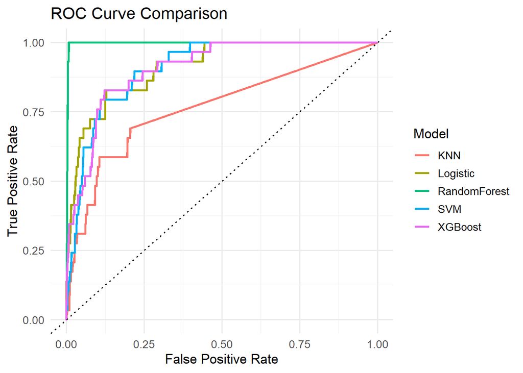

```r
svm_prob <- attr(svm_pred, "probabilities")[,'failed']
roc_svm <- roc(y_test, svm_prob)
roc_knn <- roc(y_test, knn_prob[,'failed'])
roc_logit <- roc(test_logist$y_test, logit_pred)
roc_xgb <- roc(y_test, xgb_pred)
roc_rf <- roc(test_rf$status_label_1yr, rf_prob[,'alive'])

roc_list <- list(Logistic=roc_logit, SVM=roc_svm, KNN=roc_knn, XGBoost=roc_xgb, RandomForest=roc_rf)
roc_df <- do.call(rbind, lapply(names(roc_list), function(nm) {
  data.frame(
    Model = nm,
    FPR = 1 - roc_list[[nm]]$specificities,
    TPR = roc_list[[nm]]$sensitivities
  )
}))

ggplot(roc_df, aes(x = FPR, y = TPR, color = Model)) +
  geom_line(size = 1) +
  geom_abline(slope = 1, intercept = 0, linetype = 3) +
  labs(title = "ROC Curve Comparison", x = "False Positive Rate", y = "True Positive Rate") +
  theme_minimal(base_size = 13)
```

Below is the code that retrieves the area under the curve (AUC) for these.

```r
auc_values <- c(
  Logistic = auc(roc_logit),
  SVM = auc(roc_svm),
  KNN = auc(roc_knn),
  XGBoost = auc(roc_xgb),
  RandomForest = auc(roc_rf)
)

print(round(auc_values, 4))
```

```
##     Logistic          SVM          KNN      XGBoost RandomForest
##       0.9129       0.9085       0.7633       0.9071       0.9968
```

From these AUC values, it is clear that all models except the k nearest neighbour model are performing well as they have a high AUC. The random forest model out performs all others with an AUC very close to 1. The difference between the three other models is marginal and therefore does not mean that one model is definitively better than the others. When this is the case, it is best to evaluate other performance metrics before making a decision. However, the models ranked from best to worst for AUC are. 1. Random Forest 2. Logistic Regression  
3. Support Vector Machine 4. XGBoost 5. K Nearest Neighbours

## Confusion Matrices

We can also produce the confusion matrices for all of the models.

```r
svm_conf = confusionMatrix(svm_pred, y_test, positive="failed")
knn_conf = confusionMatrix(knn_pred, y_test, positive="failed")
logit_conf = confusionMatrix(logit_class, y_test, positive="failed")
xgb_conf = confusionMatrix(xgb_class, y_test, positive="failed")
rf_conf = confusionMatrix(rf_pred, y_test, positive="failed")
```

These are printed below.

```r
message("Confusion Matrix for Support Vector Machine model: ")
```

```
## Confusion Matrix for Support Vector Machine model:
```

```r
print(svm_conf$table)
```

```
##           Reference
## Prediction alive failed
##     alive   2033      6
##     failed   359     23
```

```r
message("Confusion Matrix for K Nearest Neighbours model: ")
```

```
## Confusion Matrix for K Nearest Neighbours model:
```

```r
print(knn_conf$table)
```

```
##           Reference
## Prediction alive failed
##     alive   1898      9
##     failed   494     20
```

```r
message("Confusion Matrix for Logistic Regression model:: ")
```

```
## Confusion Matrix for Logistic Regression model::
```

```r
print(logit_conf$table)
```

```
##           Reference
## Prediction alive failed
##     alive   2391     26
##     failed     1      3
```

```r
message("Confusion Matrix for XGBoost model: ")
```

```
## Confusion Matrix for XGBoost model:
```

```r
print(xgb_conf$table)
```

```
##           Reference
## Prediction alive failed
##     alive   1971      5
##     failed   421     24
```

```r
message("Confusion Matrix for Random Forest model:: ")
```

```
## Confusion Matrix for Random Forest model::
```

```r
print(rf_conf$table)
```

```
##           Reference
## Prediction alive failed
##     alive   2371      0
##     failed    21     29
```

Both false negatives and false positives predicted within these models could be detrimental to these companies if the models were used in industry. Given that this is not the case, it is not possible to make a decision on whether having more false negatives or false positives makes a model “better”. However, it is worth noting that the logistic regression and the random forest models have significantly fewer false predictions than all other models.

## F1 Score

The F1 score is the harmonic mean of precision and recall (sensitivity), providing a balanced measure between false positives and false negatives. For this project, it gives a single summary of how effectively the model predicts bankruptcies while managing misclassification errors.

```r
svm_F1  = svm_conf$byClass['F1']
knn_F1  = knn_conf$byClass['F1']
logit_F1  = logit_conf$byClass['F1']
xgb_F1  = xgb_conf$byClass['F1']
rf_F1  = rf_conf$byClass['F1']

f1 <- c(
  SVM = svm_F1 ,
  KNN = knn_F1 ,
  Logistic = logit_F1 ,
  XGBoost = xgb_F1 ,
  RF = rf_F1
  )

print(f1)
```

```
##      SVM.F1      KNN.F1 Logistic.F1  XGBoost.F1       RF.F1
##  0.11192214  0.07366483  0.18181818  0.10126582  0.73417722
```

It is worth noting all models except for the random forest did not perform well for this metric.

## Sensitivity

```r
svm_Sensitivity = svm_conf$byClass['Sensitivity']
knn_Sensitivity = knn_conf$byClass['Sensitivity']
logit_Sensitivity = logit_conf$byClass['Sensitivity']
xgb_Sensitivity = xgb_conf$byClass['Sensitivity']
rf_Sensitivity = rf_conf$byClass['Sensitivity']

sens <- c(
  SVM = svm_Sensitivity,
  KNN = knn_Sensitivity,
  Logistic = logit_Sensitivity,
  XGBoost = xgb_Sensitivity,
  RF = rf_Sensitivity
  )

print(sens)
```

```
##      SVM.Sensitivity      KNN.Sensitivity Logistic.Sensitivity
##            0.7931034            0.6896552            0.1034483
##  XGBoost.Sensitivity       RF.Sensitivity
##            0.8275862            1.0000000
```

The models ranked from best to worst for sensitivity are. 1. Random Forest 2. XGBoost 3. Support Vector Machine 4. K Nearest Neighbours 5. Logistic Regression

It worth noting that the sensitivity metric for the logistic model is extremely low.

## Specificity

Specificity measures the proportion of actual negatives correctly classified by the model. In this context, it reflects how accurately the model recognises companies that remained solvent.

```r
svm_Specificity  = svm_conf$byClass['Specificity']
knn_Specificity  = knn_conf$byClass['Specificity']
logit_Specificity  = logit_conf$byClass['Specificity']
xgb_Specificity  = xgb_conf$byClass['Specificity']
rf_Specificity  = rf_conf$byClass['Specificity']

spec <- c(
  SVM = svm_Specificity ,
  KNN = knn_Specificity ,
  Logistic = logit_Specificity ,
  XGBoost = xgb_Specificity ,
  RF = rf_Specificity
  )

print(spec)
```

```
##      SVM.Specificity      KNN.Specificity Logistic.Specificity
##            0.8499164            0.7934783            0.9995819
##  XGBoost.Specificity       RF.Specificity
##            0.8239967            0.9912207
```

The models ranked from best to worst for specificity are. 1. Logistic Regression 2. Random Forest  
3. Support Vector Machine 4. XGBoost 5. K Nearest Neighbours

## Precision

Precision indicates the proportion of predicted positive cases that are actually correct. For this model, it shows how reliable the bankruptcy predictions are — the proportion of predicted bankruptcies that were genuine.

```r
svm_Precision  = svm_conf$byClass['Precision']
knn_Precision  = knn_conf$byClass['Precision']
logit_Precision  = logit_conf$byClass['Precision']
xgb_Precision  = xgb_conf$byClass['Precision']
rf_Precision  = rf_conf$byClass['Precision']

prec <- c(
  SVM = svm_Precision ,
  KNN = knn_Precision ,
  Logistic = logit_Precision ,
  XGBoost = xgb_Precision ,
  RF = rf_Precision
  )

print(prec)
```

```
##      SVM.Precision      KNN.Precision Logistic.Precision  XGBoost.Precision
##         0.06020942         0.03891051         0.75000000         0.05393258
##       RF.Precision
##         0.58000000
```

The models ranked from best to worst for specificity are. 1. Logistic Regression 2. Random Forest  
3. Support Vector Machine 4. XGBoost 5. K Nearest Neighbours

It is worth noting that the support vector machine, k nearest neighbours and XGBoost all have a very low precision score.

## Balanced Accurancy

Balanced accuracy is the average of sensitivity and specificity, making it a fairer measure for datasets with unequal class sizes. Since most companies in the dataset were not bankrupt, balanced accuracy provides a more representative measure of the model’s true performance than raw accuracy.

```r
svm_bal_acc  = svm_conf$byClass['Balanced Accuracy']
knn_bal_acc  = knn_conf$byClass['Balanced Accuracy']
logit_bal_acc  = logit_conf$byClass['Balanced Accuracy']
xgb_bal_acc  = xgb_conf$byClass['Balanced Accuracy']
rf_bal_acc  = rf_conf$byClass['Balanced Accuracy']

bal_acc <- c(
  SVM = svm_bal_acc ,
  KNN = knn_bal_acc ,
  Logistic = logit_bal_acc ,
  XGBoost = xgb_bal_acc ,
  RF = rf_bal_acc
  )

print(bal_acc)
```

```
##      SVM.Balanced Accuracy      KNN.Balanced Accuracy
##                  0.8215099                  0.7415667
## Logistic.Balanced Accuracy  XGBoost.Balanced Accuracy
##                  0.5515151                  0.8257914
##       RF.Balanced Accuracy
##                  0.9956104
```